# Coursework Report

*N* removed NAs: 3

*N* removed typo: 1

*N* removed <18: 22

*N* total clean: 124

| Group | *N* | *M*<sub>age</sub> | *M*<sub>rating</sub> |
| --- | --- | --- | --- |
| Control | 62 | 21.15 | 5.36 |
| Experim | 62 | 20.85 | 6.73 |

**Main analysis results**

*t*(122) = -10.5, *p* < .001

[interactive chart not shown]

[figure not shown]

[interactive chart not shown]

# Coursework Report

Analysing Data, Spring 2020

# Methods

## Design

The fundamental conceptual question which this study was based on was whether the colour red has a direct effect on women viewing men as more attractive. The main independent variable in this study was the condition the participants were in. This variable was a factor and was measured by participants being split into colour group conditions, white (control) and red (experimental), and each ranking three images from a scale of 1 (lowest scale/not attractive at all) to 9 (highest score/very attractive. It was hypothesised that women will give higher scores when they are presented with a red rimmed picture of a male, than when they are presented with a white rimmed picture of the same male. To test this hypothesis, a statistical analysis of the *t* test was essential to conclusively decide whether the results are significant, and a conclusion could be made.

# Results

We investigated whether participants would rate the photographed male differently depending on their colour group, using an independent measures *t* test. Raw data which showed results from the study was very chaotic, as can be seen from the scatterplot below.

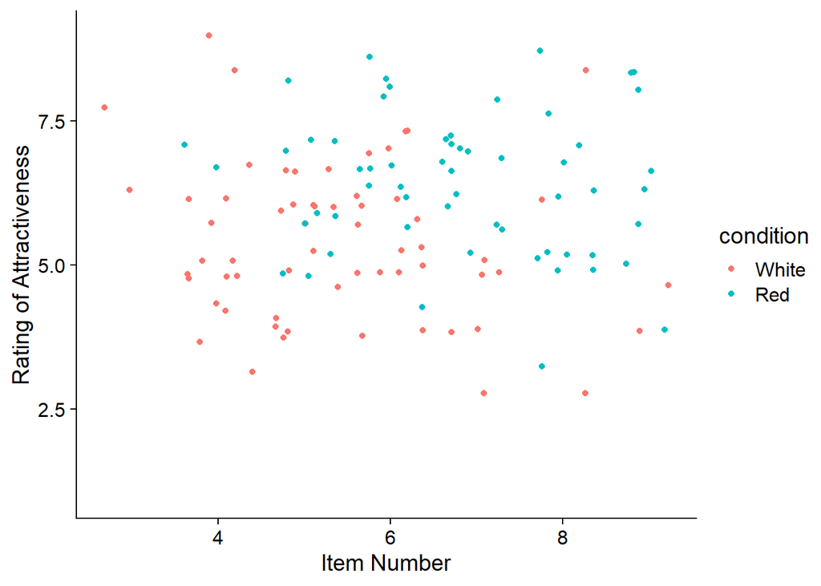

Consequently, an analysis of data was necessary to examine any correlation. The analysis indicated that, as hypothesised, the experimental colour group with a red rimmed picture gave higher mean rating of attractiveness (*M* = 6.73) than those in the control group which saw a white rimmed picture (*M* = 5.36). The difference between the two means was significant (*M*<sub>diff</sub> = 1.37, 95% CI [-1.11, -1.63], *t* (122) = -10.5, *p* = 0). The small *p* value indicates strong evidence against the null hypothesis. Additionally, the *t* value is negative, which could suggest that the sample mean is less than originally hypothesized mean, which could be evidence against the null hypothesis if the alternative was that the true mean is less than the actual sample mean The table and means plot of mean attractiveness ratings, thus the null hypothesis must be rejected and alternative hypothesis accepted. The figures shown below illustrate the analysis of mean of results further.

Mean Attractiveness ratings

| Colour Group | *M*~Rate | *SD*~Rate |
| --- | --- | --- |
| White | 5.36 | 0.69 |
| Red | 6.73 | 0.76 |

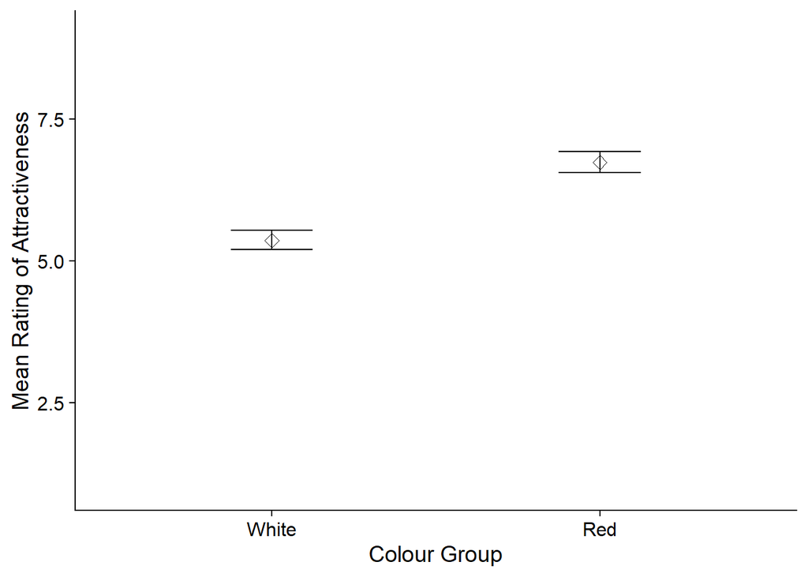

# Discussion

An important limitation of this study is that it may not be ecologically valid due to artificial stimuli of an image of a male. Due to this it may be difficult to generalise these results to the general public. Perhaps to strengthen the validity of this study, real life confederates could be used, and instead be wearing the colour red. Individual differences may also be a problem; the male images chosen may already be attractive to some woman and not to others due to different women having different tastes in men, which may affect the average scores of attractiveness. This is an even bigger issue in this study as different participants are involved in different conditions in an independent measures design. Of course, picking out specific participants or confederates and using a dependent measures design would minimise such differences but would be too time consuming, and with dependent measures also comes the issue of demand characeteristics. On the other hand, if you were to observe every participant individually and still find a positive correlation between the colour red and a greater attraction, it could be seen as even more meaningful evidence, however again, this would be time consuming. Despite the limitations, I do believe that the effect of the colour red on attractiveness is real as results of several studies consistently show the difference between the colour red and other colours, in this case white.

Other similarly set out studies have found a similar pattern of results. In the study “Men in red: A reexamination of the red attractiveness effect” by Hesslinger et al, found a slight difference in ratings between the colour red and white, however, their results were not significant as the difference was minimal with no more than .30 mean attractiveness rating difference. The patterns of results are not identical to our own study, as our mean difference in attractiveness ratings had over one rank higher, however this may be due to several factors which differed between the two studies such as participant ages etc. However, the slightest difference may still be additional to other more significant evidence such as our own, and only gives greater motivation to study this effect further.

It may be useful to investigate the research question further in different contexts. For example, a study variation could be carried out using real life confederates wearing red clothing to investigate whether or not it has any effect on others rating of attraction. This research could be beneficial for clothing brands as they can use it to boost sales by advertising of their red products. It could also be useful to research whether the colour red has the same effect on attractiveness for both genders. Does the association of the colour red also cause men to view women more attractive? There could be possible gender differences, perhaps the results could be even stronger when studying the male gender. Some studies such as “Color and women attractiveness” by Gueguen et al, have already investigated the effect of red clothing on females and whether it causes men to find woman more attractive. These findings can be used to further explore the idea of colours altering human opinions and may serve as even greater evidence for this topic of research, giving Elliot et al greater reliability. Perhaps it may be interesting to study whether it is only the colour red that causes a higher attractiveness ranking from others, and whether other colours may have a similar effect. Perhaps different colours can affect other aspects of human opinions on each other, for example does the colour blue make someone appear a more of a calm person?

In conclusion, my main findings suggest that the colour red could make someone appear more attractive as, in this study along with others, woman did in fact give a greater attractiveness score to males when they are associated with the colour red. The knowledge of this area of research could be greatly elaborated by changing several variables such as gender, therefore it should further be studied in the future as it can prove useful for areas such as sales and marketing, helping the growth of the economy.

# References

Elliot, A. J., Niesta Kayser, D., Greitemeyer, T., Lichtenfeld, S., Gramzow, R. H., Maier, M. A., & Liu, H. (2010). Red, rank, and romance in women viewing men. Journal of Experimental Psychology: General, 139(3), 399.

Hesslinger, V. M., Goldbach, L., & Carbon, C. C. (2015). Men in red: A reexamination of the red-attractiveness effect. Psychonomic bulletin & review, 22(4), 1142-1148.